# Prepare EMOTION ratings

```r
library(tidyverse)
library(janitor)

subs_file <- "/data00/leonardo/RSA/sub_list.txt"
subs <- sprintf("%02d",readLines(subs_file) %>% as.numeric)
movie_encodings_table <- read_csv("/data00/leonardo/RSA/encodings/movie_encodings.csv")
```

# Preparing the `emotion_ratings.csv` file

The final csv will be saved in `/data00/leonardo/RSA/analyses/RATINGS/emotion_ratings.csv`

This file will be used in the fmri as well as in the subsequent RSA. Note that while the participants carried out 8 runs inside the scanner, they only rated each movie once.

## Congruence testing

**IMPORTANT** : after preparing the csv file for the fmri analysis, we also conduct a simple analysis to verify sensitivity of the behavioural task. In brief, the highest rating given to any movie is hypothesized to refer to the emotion actually displayed in the movie.

Scroll down to `Examine movie/rating congruence` to see the outcome of this analysis

## Code preparation

NB: all of the code in the following cell is just for preparation. The actual conversion will be carried out with a function encompassing all of this code and carried out using `purrr` on all subs

```r
sub_id <- subs[1]

orig_root = paste0("/data00/leonardo/RSA/raw_data/sub-",sub_id,"/ratings/sub-",sub_id,"_Rating_")

# Sorry for not being DRY : there are only two files and in this way it's much clearer what is going on

# Rating EXP 1
df_EXP_1_raw_allrows <- read_csv(paste0(orig_root,"EXP1.csv")) %>% janitor::clean_names()

# select only rows below the one with "Start Real Experiment"
row_exp_start <- which(df_EXP_1_raw_allrows$display == "Start Real Experiment") + 1
df_EXP_1_raw <- df_EXP_1_raw_allrows[row_exp_start:nrow(df_EXP_1_raw_allrows),]

df_EXP_1 <- df_EXP_1_raw %>%
  filter(
    # video == "AK_A_04.mp4",
    zone_name == "Ratingintensity",
    zone_type == "response_slider_endValue"
  ) %>%
  mutate(rate_this_emo = str_extract(rating, "Fear|Pain|Anger|Happy|Sad|Disgust")) %>%
  select(video, response, video, rate_this_emo) %>%
  mutate(response = as.numeric(response))
  # pivot_wider(names_from = rate_this_emo, values_from = response)


# Rating EXP 2
df_EXP_2_raw_allrows <- read_csv(paste0(orig_root,"EXP2.csv")) %>% janitor::clean_names()

# select only rows below the one with "Start Real Experiment"
row_exp_start <- which(df_EXP_2_raw_allrows$display == "Start Real Experiment") + 1
df_EXP_2_raw <- df_EXP_2_raw_allrows[row_exp_start:nrow(df_EXP_2_raw_allrows),]

df_EXP_2 <- df_EXP_2_raw %>%
  filter(
    # video == "AK_A_04.mp4",
    zone_name == "Ratingintensity",
    zone_type == "response_slider_endValue"
  ) %>%
  mutate(rate_this_emo = str_extract(rating, "Fear|Pain|Anger|Happy|Sad|Disgust")) %>%
  select(video, response, video, rate_this_emo) %>%
  mutate(response = as.numeric(response))
  # pivot_wider(names_from = rate_this_emo, values_from = response)


# Merge the results from the two experimental runs and pivot it wider to have columns
# for the ratings for each emotion
df <- rbind(df_EXP_1, df_EXP_2)
df_wide <- df %>% pivot_wider(names_from = rate_this_emo, values_from = response)

# add columns for:
# - original_code : extracted from the movie filename
# - high_low_code : the intensity of the emotion displayed in that movie
# - emotion : the emotion displayed in that movie
# - actor : the actor performing in that movie
df_wide_codes <- df_wide %>%
  janitor::clean_names() %>%
  mutate(original_code = str_remove(video, "\\..*$")) %>%
  inner_join(movie_encodings_table, by="original_code") %>%
  rename_with(~ paste0("r_", .), c("happy","disgust","sad","fear","anger","pain") ) %>%
  arrange(high_low_code)

df_wide_codes
```

## Write the function to be passed to purrr over subs

```r
prepare_csv_ratings <- function(sub_id) {

  paste0("Processing subj ",sub_id,"\n") %>% cat

  orig_root = paste0("/data00/leonardo/RSA/raw_data/sub-",sub_id,"/ratings/sub-",sub_id,"_Rating_")

  # Sorry for not being DRY : there are only two files and in this way it's much clearer what is going on

  # Rating EXP 1
  df_EXP_1_raw_allrows <- read_csv(paste0(orig_root,"EXP1.csv")) %>% janitor::clean_names()

  # select only rows below the one with "Start Real Experiment"
  row_exp_start <- which(df_EXP_1_raw_allrows$display == "Start Real Experiment") + 1
  df_EXP_1_raw <- df_EXP_1_raw_allrows[row_exp_start:nrow(df_EXP_1_raw_allrows),]

  df_EXP_1 <- df_EXP_1_raw %>%
    filter(
      # video == "AK_A_04.mp4",
      zone_name == "Ratingintensity",
      zone_type == "response_slider_endValue"
    ) %>%
    mutate(rate_this_emo = str_extract(rating, "Fear|Pain|Anger|Happy|Sad|Disgust")) %>%
    select(video, response, video, rate_this_emo) %>%
    mutate(response = as.numeric(response))
    # pivot_wider(names_from = rate_this_emo, values_from = response)


  # Rating EXP 2
  df_EXP_2_raw_allrows <- read_csv(paste0(orig_root,"EXP2.csv")) %>% janitor::clean_names()

  # select only rows below the one with "Start Real Experiment"
  row_exp_start <- which(df_EXP_2_raw_allrows$display == "Start Real Experiment") + 1
  df_EXP_2_raw <- df_EXP_2_raw_allrows[row_exp_start:nrow(df_EXP_2_raw_allrows),]

  df_EXP_2 <- df_EXP_2_raw %>%
    filter(
      # video == "AK_A_04.mp4",
      zone_name == "Ratingintensity",
      zone_type == "response_slider_endValue"
    ) %>%
    mutate(rate_this_emo = str_extract(rating, "Fear|Pain|Anger|Happy|Sad|Disgust")) %>%
    select(video, response, video, rate_this_emo) %>%
    mutate(response = as.numeric(response))
    # pivot_wider(names_from = rate_this_emo, values_from = response)


  # Merge the results from the two experimental runs and pivot it wider to have columns
  # for the ratings for each emotion
  df <- rbind(df_EXP_1, df_EXP_2)
  df_wide <- df %>% pivot_wider(names_from = rate_this_emo, values_from = response)

  # add columns for:
  # - original_code : extracted from the movie filename
  # - high_low_code : the intensity of the emotion displayed in that movie
  # - emotion : the emotion displayed in that movie
  # - actor : the actor performing in that movie
  # - sub_id
  df_wide_codes <- df_wide %>%
    janitor::clean_names() %>%
    mutate(original_code = str_remove(video, "\\..*$")) %>%
    inner_join(movie_encodings_table, by="original_code") %>%
    rename_with(~ paste0("r_", .), c("happy","disgust","sad","fear","anger","pain") ) %>%
    arrange(high_low_code) %>%
    mutate(sub = sub_id) %>%
    relocate(sub)
}
```

## Purrr over subs, save csv, display the table

```r
ff <- subs %>% map_dfr(~ prepare_csv_ratings(.x))
```

```
Processing subj 02
Processing subj 03
Processing subj 05
Processing subj 07
Processing subj 09
Processing subj 10
Processing subj 11
Processing subj 12
Processing subj 14
Processing subj 15
Processing subj 16
Processing subj 18
Processing subj 19
Processing subj 20
Processing subj 21
Processing subj 22
Processing subj 23
Processing subj 24
Processing subj 26
Processing subj 27
Processing subj 28
Processing subj 29
Processing subj 30
Processing subj 31
Processing subj 32
Processing subj 34
```

```r
write_csv(ff, "/data00/leonardo/RSA/analyses/RATINGS/emotion_ratings.csv")

ff
```

| sub | video | r_happy | r_disgust | r_sad | r_fear | r_anger | r_pain | original_code | high_low_code | movie_cope_number | actor | emotion |
| --- | --- | --- | --- | --- | --- | --- | --- | --- | --- | --- | --- | --- |
| 02 | AK_A_32.mp4 | 0 | 0 | 0 | 0 | 0 | 8 | AK_A_32 | AK_A_high | 1 | AK | anger |
| 02 | AK_A_04.mp4 | 0 | 0 | 0 | 0 | 8 | 0 | AK_A_04 | AK_A_low | 2 | AK | anger |
| 02 | AK_D_12.mp4 | 0 | 10 | 0 | 0 | 0 | 0 | AK_D_12 | AK_D_high | 3 | AK | disgust |
| 02 | AK_D_02.mp4 | 0 | 7 | 0 | 0 | 0 | 0 | AK_D_02 | AK_D_low | 4 | AK | disgust |
| 02 | AK_F_24.mp4 | 0 | 0 | 0 | 10 | 0 | 0 | AK_F_24 | AK_F_high | 5 | AK | fear |
| 02 | AK_F_02.mp4 | 0 | 0 | 0 | 8 | 0 | 0 | AK_F_02 | AK_F_low | 6 | AK | fear |
| 02 | AK_H_15.mp4 | 10 | 0 | 0 | 0 | 0 | 0 | AK_H_15 | AK_H_high | 7 | AK | happy |
| 02 | AK_H_28.mp4 | 7 | 0 | 0 | 0 | 0 | 0 | AK_H_28 | AK_H_low | 8 | AK | happy |
| 02 | AK_N_09.mp4 | 0 | 0 | 0 | 0 | 0 | 0 | AK_N_09 | AK_N_high | 9 | AK | neutral |
| 02 | AK_N_01.mp4 | 0 | 0 | 0 | 0 | 0 | 0 | AK_N_01 | AK_N_low | 10 | AK | neutral |

[output cut: 990 more lines]

# Examine movie/rating congruence

Each movie displays a specific emotion, however the participant is requested to rate each movie for all the 6 emotions.

It is expected that across emotion rating, the highest will be for the emotion which is displayed in the movie. However it is better to verify this.

```r
df_congruence <- ff %>%
  select(sub,original_code, emotion, starts_with("r_")) %>%
  pivot_longer(starts_with("r_"), names_to = "rating") %>%
  group_by(sub, original_code, emotion) %>%
  filter(value == max(value)) %>%
  filter(value != 0) %>%
  mutate(rating = str_remove(rating,"r_")) %>%
  mutate(consistent = ifelse(emotion==rating,1,0)) %>%
  ungroup %>%
  group_by(sub) %>%
  summarise(
    congruence = round(sum(consistent)/n(),2)
  ) %>%
  arrange(congruence)

df_congruence
```

| sub | congruence |
| --- | --- |
| 07 | 0.38 |
| 34 | 0.51 |
| 24 | 0.56 |
| 10 | 0.58 |
| 16 | 0.62 |
| 31 | 0.63 |
| 30 | 0.65 |
| 27 | 0.70 |
| 05 | 0.73 |
| 21 | 0.77 |

[output cut: 16 more lines]

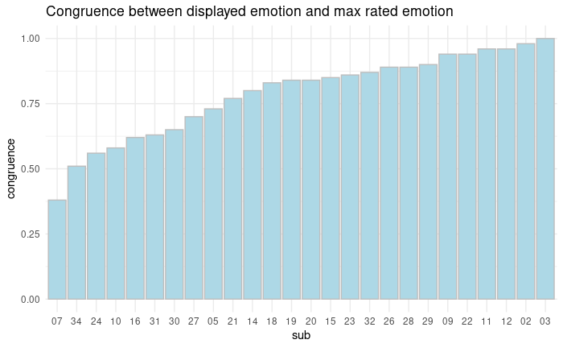

```r
df_congruence %>%
  ggplot(aes(x = reorder(sub, congruence), y = congruence)) +
  geom_bar(stat = "identity", color = "grey", fill = "lightblue") +
  theme_minimal() +
  labs(title = "Congruence between displayed emotion and max rated emotion", x = "sub")
```

## Inspect participants with low movie/rating congruence

```r
ff %>%
  filter(sub=="34") %>%
  select(sub,original_code, emotion, starts_with("r_")) %>%
  pivot_longer(starts_with("r_"), names_to = "rating") %>%
  group_by(sub, original_code, emotion) %>%
  # filter(value != 0) %>%
  arrange(desc(value)) %>%
  group_split()
```

[output not shown]

## Look also at the congruence with the second highest rated emotion

Maybe the participants with *low* congruence - when looking at the max rated emotion - did rate as second highest the actually congruent emotion? Not really.

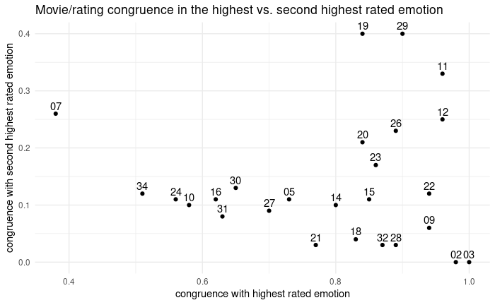

```r
df_second_highest_congruence <- ff %>%
  select(sub, original_code, emotion, starts_with("r_")) %>%
  pivot_longer(starts_with("r_"), names_to = "rating", values_to = "value") %>%
  group_by(sub, original_code, emotion) %>%
  arrange(desc(value)) %>%
  slice(2) %>%
  filter(value != 0) %>%
  mutate(rating = str_remove(rating, "r_")) %>%
  mutate(consistent = ifelse(emotion == rating, 1, 0)) %>%
  ungroup() %>%
  group_by(sub) %>%
  summarise(congruence = round(sum(consistent) / n(), 2)) %>%
  arrange(congruence)

df_second_highest_congruence %>%
  rename(second_congruence = congruence) %>%
  select(sub, second_congruence) %>%
  inner_join(df_congruence, by = "sub") %>%
  relocate(sub, congruence, second_congruence) %>%
  arrange(desc(congruence), desc(second_congruence)) %>%
  ggplot(aes(x=congruence, y=second_congruence, label=sub)) + # Add label aesthetic for sub
  geom_point() +
  geom_text(vjust=-0.5, hjust=0.5, check_overlap = TRUE) + # Add text labels for each point
  theme_minimal() +
  labs(
    title = "Movie/rating congruence in the highest vs. second highest rated emotion",
    x = "congruence with highest rated emotion",
    y = "congruence with second highest rated emotion"
  )
```